# Forgobike Exploration

## by Fatimah Ajoke Abudu Olaleye

1. IMPORTING PACKAGES
2. DATA GATHERING
3. ACCESSING DATA
4. DATA CLEANING
5. UNIVARIATE EXPLORATION
6. BIVARIATE EXPLORATION
7. MULTIVARIATE EXPLORATION
8. CONCLUSION AND REFERENCES

## Introduction

> This data set includes information about individual rides made for February, 2019 in a bike-sharing system covering the greater San Francisco Bay area and New York city.These bike share systems, with hundreds of stations and thousands of bikes across both cities. It’s a fun, affordable and convenient way to get around.

## Importing packages

```python
# import all packages and set plots to be embedded inline
import numpy as np
import pandas as pd
import matplotlib.pyplot as plt
import seaborn as sns

%matplotlib inline
```

## Data Gathering

```python
#Gathering required datasets from both cities
df_bike_CA = pd.read_csv("201902-fordgobike-tripdata_CA.csv")
df_bike_NYC = pd.read_csv("201902-citibike-tripdata_NYC.csv")
```

## ACCESSING DATA

> We would begin by accessing the datasets, starting with the San Francisco area, then moving to New York city, with a view to understand our datasets for analysis.

### SAN FRANCISCO BAY AREA

```python
df_bike_CA.head()
```

|  | duration_sec | start_time | end_time | start_station_id | start_station_name | start_station_latitude | start_station_longitude | end_station_id | end_station_name | end_station_latitude | end_station_longitude | bike_id | user_type | member_birth_year | member_gender | bike_share_for_all_trip |
| --- | --- | --- | --- | --- | --- | --- | --- | --- | --- | --- | --- | --- | --- | --- | --- | --- |
| 0 | 52185 | 2019-02-28 17:32:10.1450 | 2019-03-01 08:01:55.9750 | 21.0 | Montgomery St BART Station (Market St at 2nd St) | 37.789625 | -122.400811 | 13.0 | Commercial St at Montgomery St | 37.794231 | -122.402923 | 4902 | Customer | 1984.0 | Male | No |
| 1 | 42521 | 2019-02-28 18:53:21.7890 | 2019-03-01 06:42:03.0560 | 23.0 | The Embarcadero at Steuart St | 37.791464 | -122.391034 | 81.0 | Berry St at 4th St | 37.775880 | -122.393170 | 2535 | Customer | NaN | NaN | No |
| 2 | 61854 | 2019-02-28 12:13:13.2180 | 2019-03-01 05:24:08.1460 | 86.0 | Market St at Dolores St | 37.769305 | -122.426826 | 3.0 | Powell St BART Station (Market St at 4th St) | 37.786375 | -122.404904 | 5905 | Customer | 1972.0 | Male | No |
| 3 | 36490 | 2019-02-28 17:54:26.0100 | 2019-03-01 04:02:36.8420 | 375.0 | Grove St at Masonic Ave | 37.774836 | -122.446546 | 70.0 | Central Ave at Fell St | 37.773311 | -122.444293 | 6638 | Subscriber | 1989.0 | Other | No |
| 4 | 1585 | 2019-02-28 23:54:18.5490 | 2019-03-01 00:20:44.0740 | 7.0 | Frank H Ogawa Plaza | 37.804562 | -122.271738 | 222.0 | 10th Ave at E 15th St | 37.792714 | -122.248780 | 4898 | Subscriber | 1974.0 | Male | Yes |

```python
df_bike_CA.shape
```

```
(183412, 16)
```

```python
df_bike_CA.describe()
```

|  | duration_sec | start_station_id | start_station_latitude | start_station_longitude | end_station_id | end_station_latitude | end_station_longitude | bike_id | member_birth_year |
| --- | --- | --- | --- | --- | --- | --- | --- | --- | --- |
| count | 183412.000000 | 183215.000000 | 183412.000000 | 183412.000000 | 183215.000000 | 183412.000000 | 183412.000000 | 183412.000000 | 175147.000000 |
| mean | 726.078435 | 138.590427 | 37.771223 | -122.352664 | 136.249123 | 37.771427 | -122.352250 | 4472.906375 | 1984.806437 |
| std | 1794.389780 | 111.778864 | 0.099581 | 0.117097 | 111.515131 | 0.099490 | 0.116673 | 1664.383394 | 10.116689 |
| min | 61.000000 | 3.000000 | 37.317298 | -122.453704 | 3.000000 | 37.317298 | -122.453704 | 11.000000 | 1878.000000 |
| 25% | 325.000000 | 47.000000 | 37.770083 | -122.412408 | 44.000000 | 37.770407 | -122.411726 | 3777.000000 | 1980.000000 |
| 50% | 514.000000 | 104.000000 | 37.780760 | -122.398285 | 100.000000 | 37.781010 | -122.398279 | 4958.000000 | 1987.000000 |
| 75% | 796.000000 | 239.000000 | 37.797280 | -122.286533 | 235.000000 | 37.797320 | -122.288045 | 5502.000000 | 1992.000000 |
| max | 85444.000000 | 398.000000 | 37.880222 | -121.874119 | 398.000000 | 37.880222 | -121.874119 | 6645.000000 | 2001.000000 |

```python
df_bike_CA.info()
```

```
<class 'pandas.core.frame.DataFrame'>
RangeIndex: 183412 entries, 0 to 183411
Data columns (total 16 columns):
 #   Column                   Non-Null Count   Dtype
---  ------                   --------------   -----
 0   duration_sec             183412 non-null  int64
 1   start_time               183412 non-null  object
 2   end_time                 183412 non-null  object
 3   start_station_id         183215 non-null  float64
 4   start_station_name       183215 non-null  object
 5   start_station_latitude   183412 non-null  float64
 6   start_station_longitude  183412 non-null  float64
 7   end_station_id           183215 non-null  float64
 8   end_station_name         183215 non-null  object
 9   end_station_latitude     183412 non-null  float64
 10  end_station_longitude    183412 non-null  float64
 11  bike_id                  183412 non-null  int64
 12  user_type                183412 non-null  object
 13  member_birth_year        175147 non-null  float64
 14  member_gender            175147 non-null  object
 15  bike_share_for_all_trip  183412 non-null  object
dtypes: float64(7), int64(2), object(7)
memory usage: 22.4+ MB
```

> The San Francisco bay area datasets appear to have 183,412 records with 16 features. Let's access the New York city area in our next phase.

### ACCESSING NEW YORK CITY AREA

```python
# checking for duplicates and missing values
df_bike_NYC.head()
```

|  | tripduration | starttime | stoptime | start station id | start station name | start station latitude | start station longitude | end station id | end station name | end station latitude | end station longitude | bikeid | usertype | birth year | gender |
| --- | --- | --- | --- | --- | --- | --- | --- | --- | --- | --- | --- | --- | --- | --- | --- |
| 0 | 219 | 2019-02-01 00:00:06.2570 | 2019-02-01 00:03:46.1090 | 3494.0 | E 115 St & Lexington Ave | 40.797911 | -73.942300 | 3501.0 | E 118 St & Madison Ave | 40.801487 | -73.944251 | 33450 | Subscriber | 1989 | 1 |
| 1 | 143 | 2019-02-01 00:00:28.0320 | 2019-02-01 00:02:51.7460 | 438.0 | St Marks Pl & 1 Ave | 40.727791 | -73.985649 | 236.0 | St Marks Pl & 2 Ave | 40.728419 | -73.987140 | 25626 | Subscriber | 1990 | 1 |
| 2 | 296 | 2019-02-01 00:01:13.9870 | 2019-02-01 00:06:10.7340 | 3571.0 | Bedford Ave & Bergen St | 40.676368 | -73.952918 | 3549.0 | Grand Ave & Bergen St | 40.678045 | -73.962408 | 35568 | Subscriber | 1987 | 1 |
| 3 | 478 | 2019-02-01 00:01:14.1520 | 2019-02-01 00:09:12.7870 | 167.0 | E 39 St & 3 Ave | 40.748901 | -73.976049 | 477.0 | W 41 St & 8 Ave | 40.756405 | -73.990026 | 25045 | Subscriber | 1964 | 2 |
| 4 | 225 | 2019-02-01 00:01:49.3410 | 2019-02-01 00:05:34.4980 | 3458.0 | W 55 St & 6 Ave | 40.763094 | -73.978350 | 3443.0 | W 52 St & 6 Ave | 40.761330 | -73.979820 | 34006 | Subscriber | 1979 | 1 |

```python
#check for duplicated entries
df_bike_NYC.shape
```

```
(943744, 15)
```

```python
df_bike_NYC.describe()
```

|  | tripduration | start station id | start station latitude | start station longitude | end station id | end station latitude | end station longitude | bikeid | birth year | gender |
| --- | --- | --- | --- | --- | --- | --- | --- | --- | --- | --- |
| count | 9.437440e+05 | 943735.000000 | 943744.000000 | 943744.000000 | 943735.000000 | 943744.000000 | 943744.000000 | 943744.000000 | 943744.000000 | 943744.000000 |
| mean | 8.047733e+02 | 1614.552153 | 40.737283 | -73.982164 | 1604.586391 | 40.737153 | -73.982407 | 28968.990799 | 1979.224374 | 1.176684 |
| std | 7.509697e+03 | 1456.227953 | 0.030139 | 0.018546 | 1455.324186 | 0.029901 | 0.018603 | 6248.873530 | 12.176740 | 0.472637 |
| min | 6.100000e+01 | 72.000000 | 40.655400 | -74.017134 | 72.000000 | 40.655400 | -74.043991 | 14529.000000 | 1885.000000 | 0.000000 |
| 25% | 3.150000e+02 | 382.000000 | 40.718822 | -73.994564 | 380.000000 | 40.718822 | -73.994685 | 26013.000000 | 1970.000000 | 1.000000 |
| 50% | 5.180000e+02 | 507.000000 | 40.738274 | -73.985011 | 507.000000 | 40.738274 | -73.985649 | 30929.000000 | 1982.000000 | 1.000000 |
| 75% | 8.790000e+02 | 3263.000000 | 40.756604 | -73.972826 | 3263.000000 | 40.756405 | -73.973442 | 34045.000000 | 1989.000000 | 1.000000 |
| max | 2.403037e+06 | 3745.000000 | 40.866000 | -73.881000 | 3745.000000 | 40.866000 | -73.881000 | 37907.000000 | 2003.000000 | 2.000000 |

```python
df_bike_NYC.info()
```

```
<class 'pandas.core.frame.DataFrame'>
RangeIndex: 943744 entries, 0 to 943743
Data columns (total 15 columns):
 #   Column                   Non-Null Count   Dtype
---  ------                   --------------   -----
 0   tripduration             943744 non-null  int64
 1   starttime                943744 non-null  object
 2   stoptime                 943744 non-null  object
 3   start station id         943735 non-null  float64
 4   start station name       943735 non-null  object
 5   start station latitude   943744 non-null  float64
 6   start station longitude  943744 non-null  float64
 7   end station id           943735 non-null  float64
 8   end station name         943735 non-null  object
 9   end station latitude     943744 non-null  float64
 10  end station longitude    943744 non-null  float64
 11  bikeid                   943744 non-null  int64
 12  usertype                 943744 non-null  object
 13  birth year               943744 non-null  int64
 14  gender                   943744 non-null  int64
dtypes: float64(6), int64(4), object(5)
memory usage: 108.0+ MB
```

> The New York city datasets appear to have more records than the San Francisco area, with total records of 943,744, and 15 features. It can also be noticed, the two datasets share different column names even though they have the same feature. For the purpose of merging the both dataset, we would rename columns of NYC to the same as CA dataset columns in the cleaning phase.

## DATA CLEANING

At this phase of our analysis, we would be concentrating on cleaning some features in order to get our datasets ready for analysis. Some of which are:

- Dropping records with missing entries in the San Francisco bay area.
- Editing column names in New York city to be the same as the San Francisco bay area.
- Extracting samples without replacement from New York city to be the same as the San Francisco area.
- Replace the numeric values in NYC member gender from 0, 1 and 2, to Other, Male and Female respectively.
- Add city code to New York City (NYC), and San Francisco CA for easy record referencing after merging.
- Merging all the datasets to form a master copy.
- Change start and end time to datetime type and so on.

Let's now proceed to the clean up operation.

```python
#Copying datasets for analysis.
bike_CA = df_bike_CA.copy()
bike_NYC = df_bike_NYC.copy()
```

> **DEFINE**
> - Dropping records with missing entries in CA.

> **CODE**

```python
# Dropping NaN values
bike_CA = bike_CA.dropna().reset_index(drop=True)
```

> **TEST**

```python
bike_CA.info()
```

```
<class 'pandas.core.frame.DataFrame'>
RangeIndex: 174952 entries, 0 to 174951
Data columns (total 16 columns):
 #   Column                   Non-Null Count   Dtype
---  ------                   --------------   -----
 0   duration_sec             174952 non-null  int64
 1   start_time               174952 non-null  object
 2   end_time                 174952 non-null  object
 3   start_station_id         174952 non-null  float64
 4   start_station_name       174952 non-null  object
 5   start_station_latitude   174952 non-null  float64
 6   start_station_longitude  174952 non-null  float64
 7   end_station_id           174952 non-null  float64
 8   end_station_name         174952 non-null  object
 9   end_station_latitude     174952 non-null  float64
 10  end_station_longitude    174952 non-null  float64
 11  bike_id                  174952 non-null  int64
 12  user_type                174952 non-null  object
 13  member_birth_year        174952 non-null  float64
 14  member_gender            174952 non-null  object
 15  bike_share_for_all_trip  174952 non-null  object
dtypes: float64(7), int64(2), object(7)
memory usage: 21.4+ MB
```

> **DEFINE**
> - Edit column names in bike_NYC to be thesame as bike_CA for merging operation

> **CODE**

```python
# Renaming NYC bike sharing feature names
bike_NYC.rename(columns={'tripduration':'duration_sec','starttime':'start_time','stoptime':'end_time','start station id':'start_station_id',
                        'start station name':'start_station_name','start station latitude':'start_station_latitude','start station longitude':'start_station_longitude',
                        'end station id':'end_station_id','end station name':'end_station_name','end station latitude':'end_station_latitude',
                        'end station longitude':'end_station_longitude','bikeid':'bike_id','usertype':'user_type','birth year':'member_birth_year',
                        'gender':'member_gender'}, inplace=True)
```

> **TEST**

```python
bike_NYC.columns
```

```
Index(['duration_sec', 'start_time', 'end_time', 'start_station_id',
       'start_station_name', 'start_station_latitude',
       'start_station_longitude', 'end_station_id', 'end_station_name',
       'end_station_latitude', 'end_station_longitude', 'bike_id', 'user_type',
       'member_birth_year', 'member_gender'],
      dtype='object')
```

> **DEFINE**
> - Extract random samples of n = 174952 from NYC, to be equivalent to N of San Fracisco CA.

> **CODE**

```python
# Extracting sampling for fair judgement
bike_NYC = bike_NYC.sample(174952).reset_index(drop=True)
```

> **TEST**

```python
# display info
bike_NYC.info()
```

```
<class 'pandas.core.frame.DataFrame'>
RangeIndex: 174952 entries, 0 to 174951
Data columns (total 15 columns):
 #   Column                   Non-Null Count   Dtype
---  ------                   --------------   -----
 0   duration_sec             174952 non-null  int64
 1   start_time               174952 non-null  object
 2   end_time                 174952 non-null  object
 3   start_station_id         174952 non-null  float64
 4   start_station_name       174952 non-null  object
 5   start_station_latitude   174952 non-null  float64
 6   start_station_longitude  174952 non-null  float64
 7   end_station_id           174952 non-null  float64
 8   end_station_name         174952 non-null  object
 9   end_station_latitude     174952 non-null  float64
 10  end_station_longitude    174952 non-null  float64
 11  bike_id                  174952 non-null  int64
 12  user_type                174952 non-null  object
 13  member_birth_year        174952 non-null  int64
 14  member_gender            174952 non-null  int64
dtypes: float64(6), int64(4), object(5)
memory usage: 20.0+ MB
```

> **DEFINE**
> - Replace the numeric values in NYC member gender from 0, 1 and 2, to Other, Male and Female respectively.

> **CODE**

```python
# Replacing values in NYC bike member gender.
bike_NYC.member_gender = bike_NYC['member_gender'].replace([0,1,2],['Other','Male','Female'])
```

> **TEST**

```python
bike_NYC.member_gender.unique()
```

```
array(['Male', 'Other', 'Female'], dtype=object)
```

> **DEFINE**
> - Add city code to New York City (NYC), and San Francisco CA for easy record referencing after merging.

> **CODE**

```python
# Creating a new column for state code.
bike_NYC['state_code'] = 'NYC'
bike_CA['state_code'] = 'CA'
```

> **TEST**

```python
# display info for NYC
bike_NYC.head()
```

|  | duration_sec | start_time | end_time | start_station_id | start_station_name | start_station_latitude | start_station_longitude | end_station_id | end_station_name | end_station_latitude | end_station_longitude | bike_id | user_type | member_birth_year | member_gender | state_code |
| --- | --- | --- | --- | --- | --- | --- | --- | --- | --- | --- | --- | --- | --- | --- | --- | --- |
| 0 | 1752 | 2019-02-26 17:31:34.0380 | 2019-02-26 18:00:46.7900 | 477.0 | W 41 St & 8 Ave | 40.756405 | -73.990026 | 337.0 | Old Slip & Front St | 40.703799 | -74.008387 | 28282 | Subscriber | 1977 | Male | NYC |
| 1 | 120 | 2019-02-25 20:03:53.8950 | 2019-02-25 20:05:53.9530 | 351.0 | Front St & Maiden Ln | 40.705310 | -74.006126 | 264.0 | Maiden Ln & Pearl St | 40.707065 | -74.007319 | 35331 | Subscriber | 1989 | Male | NYC |
| 2 | 117 | 2019-02-27 08:38:35.2840 | 2019-02-27 08:40:32.5730 | 3416.0 | 7 Ave & Park Pl | 40.677615 | -73.973243 | 3346.0 | Berkeley Pl & 7 Ave | 40.675147 | -73.975232 | 34342 | Subscriber | 1982 | Other | NYC |
| 3 | 217 | 2019-02-08 14:08:39.7080 | 2019-02-08 14:12:17.0810 | 3628.0 | Lenox Ave & W 117 St | 40.802557 | -73.949078 | 3630.0 | Frederick Douglass Blvd & W 115 St | 40.803865 | -73.955931 | 27828 | Subscriber | 1993 | Male | NYC |
| 4 | 112 | 2019-02-26 00:32:47.7710 | 2019-02-26 00:34:40.2320 | 3511.0 | Adam Clayton Powell Blvd & W 115 St | 40.802535 | -73.953242 | 3534.0 | Frederick Douglass Blvd & W 117 St | 40.805159 | -73.954692 | 34373 | Subscriber | 1986 | Male | NYC |

```python
# display info for CA
bike_CA.head()
```

|  | duration_sec | start_time | end_time | start_station_id | start_station_name | start_station_latitude | start_station_longitude | end_station_id | end_station_name | end_station_latitude | end_station_longitude | bike_id | user_type | member_birth_year | member_gender | bike_share_for_all_trip | state_code |
| --- | --- | --- | --- | --- | --- | --- | --- | --- | --- | --- | --- | --- | --- | --- | --- | --- | --- |
| 0 | 52185 | 2019-02-28 17:32:10.1450 | 2019-03-01 08:01:55.9750 | 21.0 | Montgomery St BART Station (Market St at 2nd St) | 37.789625 | -122.400811 | 13.0 | Commercial St at Montgomery St | 37.794231 | -122.402923 | 4902 | Customer | 1984.0 | Male | No | CA |
| 1 | 61854 | 2019-02-28 12:13:13.2180 | 2019-03-01 05:24:08.1460 | 86.0 | Market St at Dolores St | 37.769305 | -122.426826 | 3.0 | Powell St BART Station (Market St at 4th St) | 37.786375 | -122.404904 | 5905 | Customer | 1972.0 | Male | No | CA |
| 2 | 36490 | 2019-02-28 17:54:26.0100 | 2019-03-01 04:02:36.8420 | 375.0 | Grove St at Masonic Ave | 37.774836 | -122.446546 | 70.0 | Central Ave at Fell St | 37.773311 | -122.444293 | 6638 | Subscriber | 1989.0 | Other | No | CA |
| 3 | 1585 | 2019-02-28 23:54:18.5490 | 2019-03-01 00:20:44.0740 | 7.0 | Frank H Ogawa Plaza | 37.804562 | -122.271738 | 222.0 | 10th Ave at E 15th St | 37.792714 | -122.248780 | 4898 | Subscriber | 1974.0 | Male | Yes | CA |
| 4 | 1793 | 2019-02-28 23:49:58.6320 | 2019-03-01 00:19:51.7600 | 93.0 | 4th St at Mission Bay Blvd S | 37.770407 | -122.391198 | 323.0 | Broadway at Kearny | 37.798014 | -122.405950 | 5200 | Subscriber | 1959.0 | Male | No | CA |

> **DEFINE**
> - Merging all the datasets to form a master copy.

> **CODE**

```python
# Merging all datasets.
master_bike_df = pd.concat([bike_NYC,bike_CA],ignore_index=True)
```

> **TEST**

```python
# display info
master_bike_df.head()
```

|  | duration_sec | start_time | end_time | start_station_id | start_station_name | start_station_latitude | start_station_longitude | end_station_id | end_station_name | end_station_latitude | end_station_longitude | bike_id | user_type | member_birth_year | member_gender | state_code | bike_share_for_all_trip |
| --- | --- | --- | --- | --- | --- | --- | --- | --- | --- | --- | --- | --- | --- | --- | --- | --- | --- |
| 0 | 1752 | 2019-02-26 17:31:34.0380 | 2019-02-26 18:00:46.7900 | 477.0 | W 41 St & 8 Ave | 40.756405 | -73.990026 | 337.0 | Old Slip & Front St | 40.703799 | -74.008387 | 28282 | Subscriber | 1977.0 | Male | NYC | NaN |
| 1 | 120 | 2019-02-25 20:03:53.8950 | 2019-02-25 20:05:53.9530 | 351.0 | Front St & Maiden Ln | 40.705310 | -74.006126 | 264.0 | Maiden Ln & Pearl St | 40.707065 | -74.007319 | 35331 | Subscriber | 1989.0 | Male | NYC | NaN |
| 2 | 117 | 2019-02-27 08:38:35.2840 | 2019-02-27 08:40:32.5730 | 3416.0 | 7 Ave & Park Pl | 40.677615 | -73.973243 | 3346.0 | Berkeley Pl & 7 Ave | 40.675147 | -73.975232 | 34342 | Subscriber | 1982.0 | Other | NYC | NaN |
| 3 | 217 | 2019-02-08 14:08:39.7080 | 2019-02-08 14:12:17.0810 | 3628.0 | Lenox Ave & W 117 St | 40.802557 | -73.949078 | 3630.0 | Frederick Douglass Blvd & W 115 St | 40.803865 | -73.955931 | 27828 | Subscriber | 1993.0 | Male | NYC | NaN |
| 4 | 112 | 2019-02-26 00:32:47.7710 | 2019-02-26 00:34:40.2320 | 3511.0 | Adam Clayton Powell Blvd & W 115 St | 40.802535 | -73.953242 | 3534.0 | Frederick Douglass Blvd & W 117 St | 40.805159 | -73.954692 | 34373 | Subscriber | 1986.0 | Male | NYC | NaN |

> **DEFINE**
> - Change start and end time to datetime type

> **CODE**

```python
#covert date columns to datetime datatype
cols = master_bike_df.columns[1:3]
master_bike_df[cols] = master_bike_df[cols].apply(pd.to_datetime, errors='coerce')
```

> **TEST**

```python
master_bike_df.info()
```

```
<class 'pandas.core.frame.DataFrame'>
RangeIndex: 349904 entries, 0 to 349903
Data columns (total 17 columns):
 #   Column                   Non-Null Count   Dtype
---  ------                   --------------   -----
 0   duration_sec             349904 non-null  int64
 1   start_time               349904 non-null  datetime64[ns]
 2   end_time                 349904 non-null  datetime64[ns]
 3   start_station_id         349904 non-null  float64
 4   start_station_name       349904 non-null  object
 5   start_station_latitude   349904 non-null  float64
 6   start_station_longitude  349904 non-null  float64
 7   end_station_id           349904 non-null  float64
 8   end_station_name         349904 non-null  object
 9   end_station_latitude     349904 non-null  float64
 10  end_station_longitude    349904 non-null  float64
 11  bike_id                  349904 non-null  int64
 12  user_type                349904 non-null  object
 13  member_birth_year        349904 non-null  float64
 14  member_gender            349904 non-null  object
 15  state_code               349904 non-null  object
 16  bike_share_for_all_trip  174952 non-null  object
dtypes: datetime64[ns](2), float64(7), int64(2), object(6)
memory usage: 45.4+ MB
```

It would be a nice idea to have the ages of users in years to have an overview of age distribution.

> **DEFINE**
> - Obtain Age column in years

> **CODE**

```python
#lets obtain the age from member_birth_year further analysis

master_bike_df['member_age'] = master_bike_df.start_time.dt.year - master_bike_df['member_birth_year']
```

> **TEST**

```python
# Display datasets
master_bike_df.head()
```

|  | duration_sec | start_time | end_time | start_station_id | start_station_name | start_station_latitude | start_station_longitude | end_station_id | end_station_name | end_station_latitude | end_station_longitude | bike_id | user_type | member_birth_year | member_gender | state_code | bike_share_for_all_trip | member_age |
| --- | --- | --- | --- | --- | --- | --- | --- | --- | --- | --- | --- | --- | --- | --- | --- | --- | --- | --- |
| 0 | 1752 | 2019-02-26 17:31:34.038 | 2019-02-26 18:00:46.790 | 477.0 | W 41 St & 8 Ave | 40.756405 | -73.990026 | 337.0 | Old Slip & Front St | 40.703799 | -74.008387 | 28282 | Subscriber | 1977.0 | Male | NYC | NaN | 42.0 |
| 1 | 120 | 2019-02-25 20:03:53.895 | 2019-02-25 20:05:53.953 | 351.0 | Front St & Maiden Ln | 40.705310 | -74.006126 | 264.0 | Maiden Ln & Pearl St | 40.707065 | -74.007319 | 35331 | Subscriber | 1989.0 | Male | NYC | NaN | 30.0 |
| 2 | 117 | 2019-02-27 08:38:35.284 | 2019-02-27 08:40:32.573 | 3416.0 | 7 Ave & Park Pl | 40.677615 | -73.973243 | 3346.0 | Berkeley Pl & 7 Ave | 40.675147 | -73.975232 | 34342 | Subscriber | 1982.0 | Other | NYC | NaN | 37.0 |
| 3 | 217 | 2019-02-08 14:08:39.708 | 2019-02-08 14:12:17.081 | 3628.0 | Lenox Ave & W 117 St | 40.802557 | -73.949078 | 3630.0 | Frederick Douglass Blvd & W 115 St | 40.803865 | -73.955931 | 27828 | Subscriber | 1993.0 | Male | NYC | NaN | 26.0 |
| 4 | 112 | 2019-02-26 00:32:47.771 | 2019-02-26 00:34:40.232 | 3511.0 | Adam Clayton Powell Blvd & W 115 St | 40.802535 | -73.953242 | 3534.0 | Frederick Douglass Blvd & W 117 St | 40.805159 | -73.954692 | 34373 | Subscriber | 1986.0 | Male | NYC | NaN | 33.0 |

Next, We would be categorising the member age.

> **DEFINE**
> - Making member_age categorial

> **CODE**

```python
# categorising using pd.cut() function
bin_edges = [16,28,34,44,141]
bin_labels = ["Teens","Young_Adults","Middle-aged_Adults","old_Adults"]
master_bike_df["age_category"] = pd.cut(master_bike_df.member_age,bins=bin_edges,labels=bin_labels,include_lowest=True)
```

> **TEST**

```python
master_bike_df.age_category.head()
```

```
0    Middle-aged_Adults
1          Young_Adults
2    Middle-aged_Adults
3                 Teens
4          Young_Adults
Name: age_category, dtype: category
Categories (4, object): ['Teens' < 'Young_Adults' < 'Middle-aged_Adults' < 'old_Adults']
```

Next, We would be making user_type, member_gender, state_code, and age_category into ordered categorical types.

> **DEFINE**
> - Making user_type,member_gender, state code, and age_category a categorical type

> **CODE**

```python
# making user_type, member_gender, state code, and age category into ordered categorical type.
ordinal_var_dict = {'member_gender':['Male','Other', 'Female'],'user_type':['Customer', 'Subscriber'],
                    'state_code':['NYC','CA'], 'age_category':["Teens","Young_Adults","Middle-aged_Adults","old_Adults"]}

for var in ordinal_var_dict:
    ordered_var = pd.api.types.CategoricalDtype(ordered = True,
                                                categories = ordinal_var_dict[var])
    master_bike_df[var] = master_bike_df[var].astype(ordered_var)
```

> **TEST**

```python
master_bike_df.dtypes
```

```
duration_sec                        int64
start_time                 datetime64[ns]
end_time                   datetime64[ns]
start_station_id                  float64
start_station_name                 object
start_station_latitude            float64
start_station_longitude           float64
end_station_id                    float64
end_station_name                   object
end_station_latitude              float64
end_station_longitude             float64
bike_id                             int64
user_type                        category
member_birth_year                 float64
member_gender                    category
state_code                       category
bike_share_for_all_trip            object
member_age                        float64
age_category                     category
dtype: object
```

> We have now successfully obtained a dataset for our exploration. Let's proceed to our exploration in the next sections.

## EXPLORATION

> As obtained from our clean up operation, we have master datasets which would be used for our analysis. The datasets contain bike ride information from both cities of interest covering the month of February ride. Let's have a preview of the datasets we would be working with in our next line of codes.

```python
# accessing datasets
master_bike_df.head()
```

|  | duration_sec | start_time | end_time | start_station_id | start_station_name | start_station_latitude | start_station_longitude | end_station_id | end_station_name | end_station_latitude | end_station_longitude | bike_id | user_type | member_birth_year | member_gender | state_code | bike_share_for_all_trip | member_age | age_category |
| --- | --- | --- | --- | --- | --- | --- | --- | --- | --- | --- | --- | --- | --- | --- | --- | --- | --- | --- | --- |
| 0 | 1752 | 2019-02-26 17:31:34.038 | 2019-02-26 18:00:46.790 | 477.0 | W 41 St & 8 Ave | 40.756405 | -73.990026 | 337.0 | Old Slip & Front St | 40.703799 | -74.008387 | 28282 | Subscriber | 1977.0 | Male | NYC | NaN | 42.0 | Middle-aged_Adults |
| 1 | 120 | 2019-02-25 20:03:53.895 | 2019-02-25 20:05:53.953 | 351.0 | Front St & Maiden Ln | 40.705310 | -74.006126 | 264.0 | Maiden Ln & Pearl St | 40.707065 | -74.007319 | 35331 | Subscriber | 1989.0 | Male | NYC | NaN | 30.0 | Young_Adults |
| 2 | 117 | 2019-02-27 08:38:35.284 | 2019-02-27 08:40:32.573 | 3416.0 | 7 Ave & Park Pl | 40.677615 | -73.973243 | 3346.0 | Berkeley Pl & 7 Ave | 40.675147 | -73.975232 | 34342 | Subscriber | 1982.0 | Other | NYC | NaN | 37.0 | Middle-aged_Adults |
| 3 | 217 | 2019-02-08 14:08:39.708 | 2019-02-08 14:12:17.081 | 3628.0 | Lenox Ave & W 117 St | 40.802557 | -73.949078 | 3630.0 | Frederick Douglass Blvd & W 115 St | 40.803865 | -73.955931 | 27828 | Subscriber | 1993.0 | Male | NYC | NaN | 26.0 | Teens |
| 4 | 112 | 2019-02-26 00:32:47.771 | 2019-02-26 00:34:40.232 | 3511.0 | Adam Clayton Powell Blvd & W 115 St | 40.802535 | -73.953242 | 3534.0 | Frederick Douglass Blvd & W 117 St | 40.805159 | -73.954692 | 34373 | Subscriber | 1986.0 | Male | NYC | NaN | 33.0 | Young_Adults |

```python
# datasets statistics
master_bike_df.describe()
```

|  | duration_sec | start_station_id | start_station_latitude | start_station_longitude | end_station_id | end_station_latitude | end_station_longitude | bike_id | member_birth_year | member_age |
| --- | --- | --- | --- | --- | --- | --- | --- | --- | --- | --- |
| count | 3.499040e+05 | 349904.000000 | 349904.000000 | 349904.000000 | 349904.000000 | 349904.000000 | 349904.000000 | 349904.000000 | 349904.000000 | 349904.000000 |
| mean | 7.574905e+02 | 878.379984 | 39.254284 | -98.166923 | 871.229643 | 39.254308 | -98.166843 | 16721.736202 | 1982.022746 | 36.977254 |
| std | 4.717116e+03 | 1270.831724 | 1.484917 | 24.185018 | 1267.197569 | 1.484741 | 24.184673 | 13065.681600 | 11.515397 | 11.515397 |
| min | 6.100000e+01 | 3.000000 | 37.317298 | -122.453704 | 3.000000 | 37.317298 | -122.453704 | 11.000000 | 1878.000000 | 16.000000 |
| 25% | 3.190000e+02 | 102.000000 | 37.780760 | -122.398279 | 99.000000 | 37.781010 | -122.397437 | 4960.000000 | 1975.000000 | 28.000000 |
| 50% | 5.140000e+02 | 298.000000 | 39.267811 | -97.945627 | 296.000000 | 39.267811 | -97.959055 | 10587.000000 | 1985.000000 | 34.000000 |
| 75% | 8.290000e+02 | 508.000000 | 40.739126 | -73.984907 | 505.000000 | 40.738274 | -73.985649 | 30922.000000 | 1991.000000 | 44.000000 |
| max | 1.119152e+06 | 3745.000000 | 40.814394 | -73.907744 | 3745.000000 | 40.814394 | -73.907744 | 37907.000000 | 2003.000000 | 141.000000 |

```python
# datasets structure
master_bike_df.shape
```

```
(349904, 19)
```

### What is/are the main feature(s) of interest in your dataset?

> I'm most interested in comparing the two states, NYC and CA. Afterwhich, I plan in figuring out what factors are best for predicting the duration of Individual bike ride in the dataset.

### What features in the dataset do you think will help support your investigation into your feature(s) of interest?

> I expect the user_type and member_age will have the strongest effect on the duration of an individual bike ride.

## Univariate Exploration

> I would begin by looking at main variables of interests, duration in seconds and member age, which are both numeric data types.

### What is the distribution of duration in the datasets?

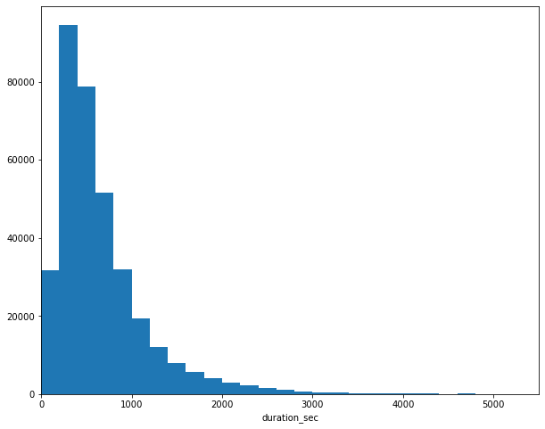

```python
def dist_plot(arg,size,xliml,xlimu):
    '''Plotting on a standard scaled plot'''
    bins = np.arange(0, master_bike_df[arg].max()+size, size)
    plt.figure(figsize=[10, 8])
    plt.hist(data = master_bike_df, x = arg, bins = bins)
    plt.xlabel(arg)
    plt.xlim(xliml,xlimu)
    plt.show()

dist_plot('duration_sec',200,0,5500)
```

> The distribution appears to be skewed to the right, with a lot of bike rides at the lower duration, lying less than 5000, with its peak between 0 and 1000. Let's consider a transformation to obtain better insights.

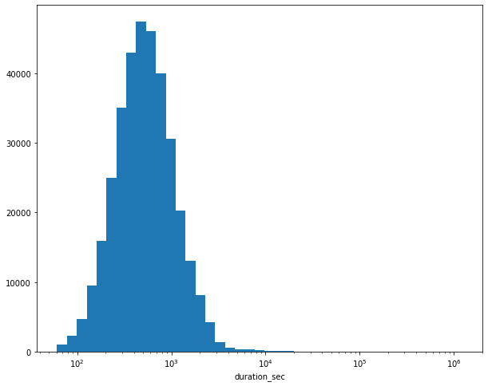

```python
# Plotting using log transformation
def dist_trans(arg,size):
    ''' Plotting on a log transformation'''
    maximum = np.log10(master_bike_df[arg].max())
    minimum = np.log10(master_bike_df[arg].min())
    bins = 10 ** np.arange(minimum,maximum + size, size)
    plt.figure(figsize=[10,8])
    plt.hist(data=master_bike_df, x=arg, bins=bins)
    plt.xscale('log')
    #plt.xticks([100,1e3,1e4,1e5,1e6],[100,'1k','10k','100k','1M'])
    plt.xlabel(arg)
    plt.show()


dist_trans('duration_sec',0.105)
```

> Plotting on a log scale, the duration is highly concentrated at the centre, with a unimodal shape. Its peak is between 500 and 1000. Next up, is the age distribution.

## What is the overall age distribution?

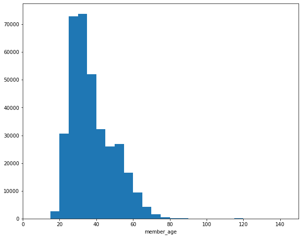

```python
# Obtaining the histogram distribution of member age
dist_plot('member_age',5,0,150)
```

> Similar to duration distribution, the age distribution appears to also be skewed to the right with concentration of ages between 25 to 40 from both city datasets. Let's see what it looks like on a log scale.

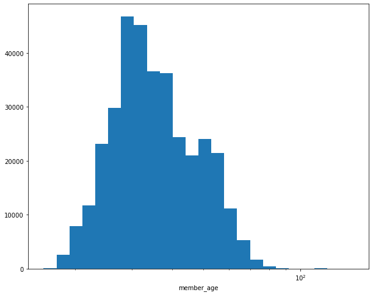

```python
# Plotting the transformed member age using log transformation
dist_trans('member_age',0.04)
```

> A further reduction in the bin would only increase noise in our plot. The distribution of ages on a log scale appears to be roughly unimodal. Next, let's have a view of the total counts of the age categories, user types, and member gender in our datasets.

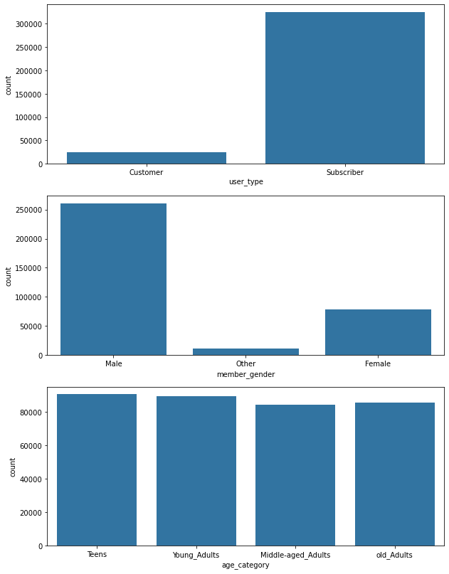

```python
# plotting all three to get idea of each categorical variable distribution.
categoric_vars = ['user_type','member_gender','age_category']
fig, ax = plt.subplots(nrows=3, figsize = [10,14])

color = sns.color_palette()[0]
for var in categoric_vars:
    sns.countplot(data = master_bike_df, x = var, ax = ax[categoric_vars.index(var)], color=color)
plt.show()
```

> Shown by the graph output, it can be seen there are more subscribers to customers, of which are more males than females, with teens and young adults, of age 18 - 34 taking majority of the members in both city datasets. In summary, it can be said there are more male subscribers, between the ages of 18 to 34 from both New York and San Francisco city bike ride datasets. The next insights we would love to investigate are trips with respect to day of the week.

### When are most trips taken in terms day of the week?

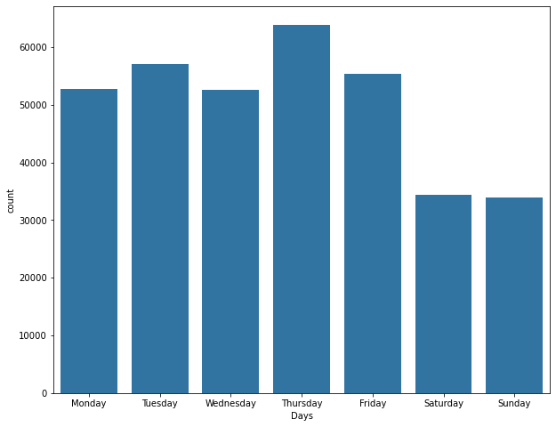

```python
master_bike_df['trip_day'] =  master_bike_df.start_time.dt.day_name()
# plotting counts with respect to day of week
color = sns.color_palette()[0]
plt.figure(figsize=[10,8])
sns.countplot(data=master_bike_df, x='trip_day', color=color,
              order=['Monday','Tuesday','Wednesday','Thursday','Friday','Saturday','Sunday']);
plt.xlabel("Days");
```

> Visualisation output above, shows Thursday to be the highest ride days, followed by Tuesday and Friday, the least on Saturdays and Sundays. Likeable causes are work related activities, most probably members take on trips for rides to work. Note this is just an assumption, a further could aid yielding likeable causes.

### Discuss the distribution(s) of your variable(s) of interest. Were there any unusual points? Did you need to perform any transformations?

> The duration and age variable took on a large range of values, highly skewed to the right with a long tail. As a result, I looked at the data using a log transform. Under the transformation, the data looked unimodal, with duration peak between 500 and 1000, and age distribution between 25 to 50 for the overall datasets.

### Of the features you investigated, were there any unusual distributions? Did you perform any operations on the data to tidy, adjust, or change the form of the data? If so, why did you do this?

> No tidiness issues were adjusted during the cause of analysis. Except for dirty data that was properly addressed in the cleaning phase of our analysis.

## Bivariate Exploration

> In this section, we would be investigating the relationships between duration, age and the categorical variables.

```python
# compute the logarithm transformation of age and duration make plotting easier
def log_trans(x, inverse = False):
    """ quick function for computing log and power operations """
    if not inverse:
        return np.log10(x)
    else:
        return np.power(10, x)

master_bike_df['log_duration'] = master_bike_df['duration_sec'].apply(log_trans)
master_bike_df['log_age'] = master_bike_df['member_age'].apply(log_trans)
```

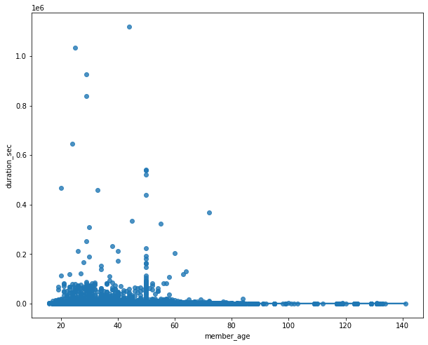

```python
def reg_plot(x,y):
    ''' Plotting scatter graph to show relationship '''
    plt.figure(figsize=[10,8])
    sns.regplot(data=master_bike_df, x=x, y=y);

reg_plot('member_age','duration_sec')
```

> Apart from the fact the above graph takes a longer time to compute, it also shows no significant relationship. Let's further dig to see if we could have anything meaningful from plotting using log scale.

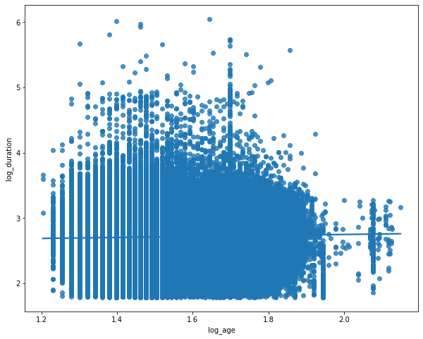

```python
# Plotting on log transformation
reg_plot('log_age','log_duration')
```

> Although the above graph of age against duration is clearer on a log scale, it still shows no significant relationship between both variables. It would be a smarter idea to have a sample extracted from the dataset, to fasten computation and render plots clearer. This would be done in our next line of code.

```python
# Extracting n samples
samples = np.random.choice(master_bike_df.shape[0], 2000, replace = False)
bike_samp = master_bike_df.loc[samples,:]
```

### What is the relationship between categorical variables and duration?

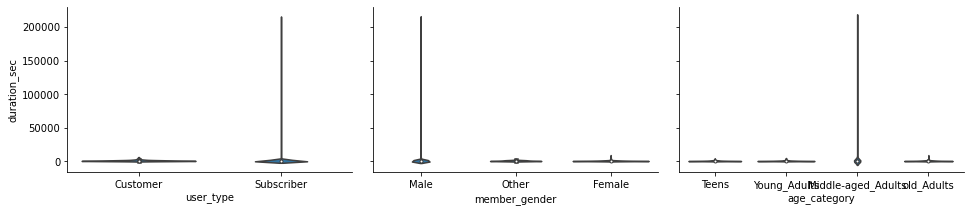

```python
#plotting categorical variables against duration
def boxgrid(x, y, **kwargs):
    """ Quick hack for creating box plots with seaborn's PairGrid. """
    default_color = sns.color_palette()[0]
    sns.violinplot(x, y, color = default_color);

plt.figure(figsize = [10, 24]);
g = sns.PairGrid(data = bike_samp, y_vars = ['duration_sec'], x_vars = categoric_vars,
                size = 3, aspect = 1.5);
g.map(boxgrid);
plt.show();
```

> Limiting to sample size of n = 2000, we still can't get a clearer plot for obtaining. Let's plot on a log scale to see if it helps.

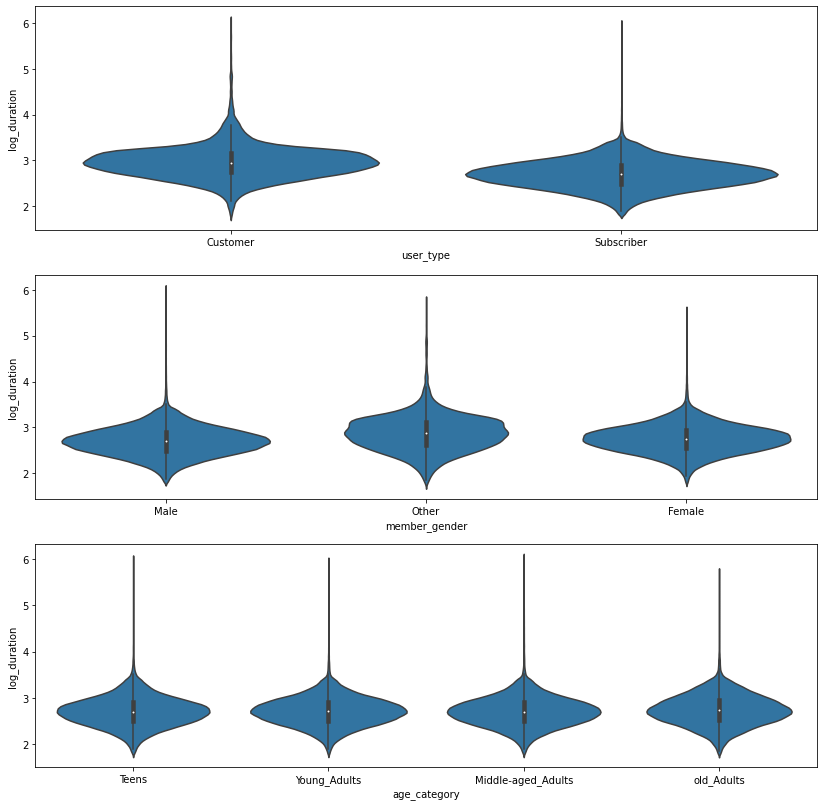

```python
# Plotting categorical variables against log duration for the whole datasets.
color = sns.color_palette()[0]
fig, ax = plt.subplots(ncols = 1, nrows = 3 , figsize = [14,14])
for i in range(len(categoric_vars)):
    var = categoric_vars[i]
    sns.violinplot(data = master_bike_df, x = var, y = 'log_duration', ax = ax[i], color=color)

plt.show()
```

> The log scale appears to work for clear plotting, We see that the overall shape and distribution of the tips are similar in most cases. The violin plot shows the relationship of duration on a log scale and the categorical variables. The quartiles are very close to each other, and the datasets are highly concentrated at the median with a long tail after the third quartile, signifying presence of outliers in all cases. Let's move ahead to comparing the categorical variables.

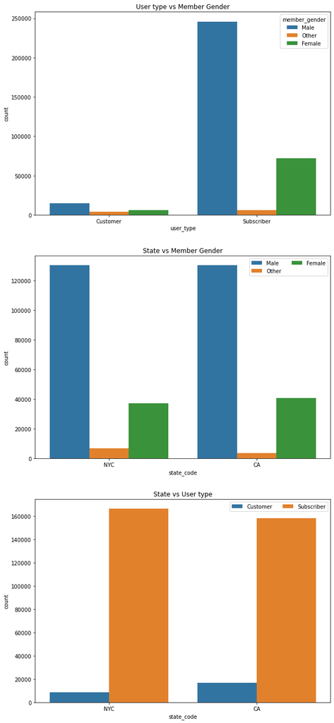

```python
# since there's only three subplots to create, using the full data should be fine.
plt.figure(figsize = [10, 24])

# subplot 1: user type vs member gender
plt.subplot(3, 1, 1)
plt.title('User type vs Member Gender')
sns.countplot(data = master_bike_df, x = 'user_type', hue = 'member_gender')

# subplot 2: state code vs. member gender
ax = plt.subplot(3, 1, 2)
plt.title('State vs Member Gender')
sns.countplot(data = master_bike_df, x = 'state_code', hue = 'member_gender')
ax.legend(ncol = 2) # re-arrange legend to reduce overlapping

# subplot 3: state_code vs. user type, use different color palette
ax = plt.subplot(3, 1, 3)
plt.title('State vs User type')
sns.countplot(data = master_bike_df, x = 'state_code', hue = 'user_type')
ax.legend(loc = 1, ncol = 2) # re-arrange legend to remove overlapping

plt.show()
```

> From an earlier univariate plot of categorical variables, it was stated there exist more male subscribers. The above graph further drives our point, but this time with a look at city comparison. It can be seen there are more male riders than females, and more subscribers than customers in both New York city and San Francisco bay area bike datasets. Let's take a look at day with respect to user and then gender in our next analysis.

## Which of day of week have most trips corresponding to user type?

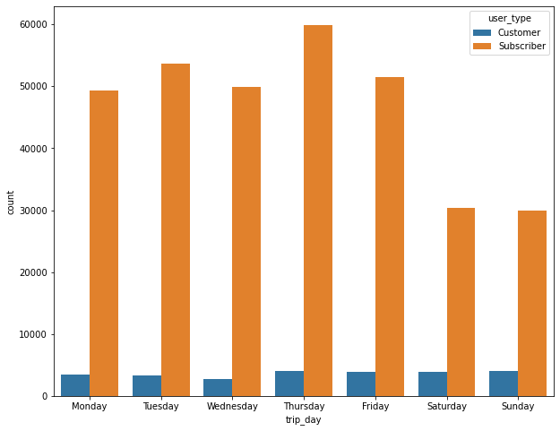

```python
# plotting days vs user type
def day_trip(arg):
    ''' Plotting day of the week corresponding to arg'''
    color = sns.color_palette()[0]
    plt.figure(figsize=[10,8])
    sns.countplot(data=master_bike_df, x='trip_day',
              order=['Monday','Tuesday','Wednesday','Thursday','Friday','Saturday','Sunday'], hue=arg);

day_trip('user_type')
```

> The above graph still further buttresses the point in univariate analysis, which shows Thursday being the highest day trip taken. In this case, we have a better insight based on user type classification. Subscriber users still appear to be highest on Thursdays, followed by Tuesday and Friday. Saturday and Sunday were the lowest days, but Wednesday appears to be the lowest for customer users.

## Which of day of week have most trips corresponding to gender?

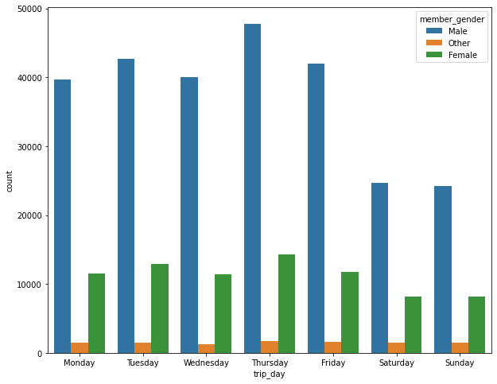

```python
# Plotting day against gender
day_trip('member_gender')
```

> Male members appear to have the highest ride on Thursdays according to the above plot, with lowest on weekends.

### Talk about some of the relationships you observed in this part of the investigation. How did the feature(s) of interest vary with other features in the dataset?

> There appears to be no significant relationship between age and duration. All categorical variables show no relationships rather than more participation of male subscribers on Thursdays.

## Multivariate Exploration

> In this section, we would be investigating the duration of rides per day of week, with respect to cities and categorical variables, with a viewing of comparing both cities' rides, if there could be any notable insight to be observed.

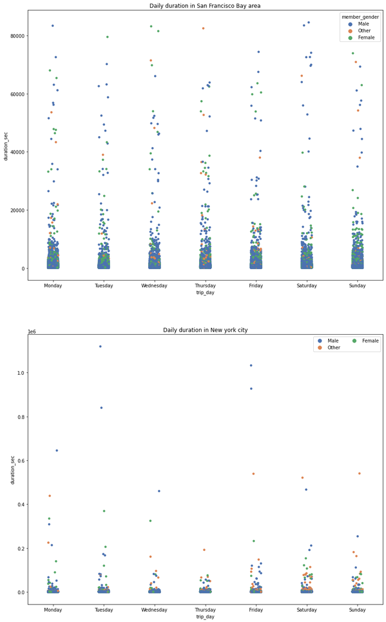

```python
# Querying city rides
data_CA = master_bike_df.query('state_code == "CA"')
data_NYC = master_bike_df.query('state_code =="NYC"')

#Plotting day vs duration corresponding to individual cities and categorical variables.
def compare_plot(arr):
    ''' Plotting to compare cities against passed arr'''
    # since there's only three subplots to create, using the full data should be fine.
    plt.figure(figsize = [14, 24])

    # subplot 1: duration vs arr in SA
    plt.subplot(2, 1, 1)
    plt.title('Daily duration in San Francisco Bay area')
    sns.stripplot(data=data_CA, x='trip_day', y='duration_sec', hue=arr,
             order=['Monday','Tuesday','Wednesday','Thursday','Friday','Saturday','Sunday'], palette='deep');

    # subplot 2: duration vs arr in NYC
    ax = plt.subplot(2, 1, 2)
    plt.title('Daily duration in New york city')
    sns.stripplot(data=data_NYC, x='trip_day', y='duration_sec', hue=arr,
             order=['Monday','Tuesday','Wednesday','Thursday','Friday','Saturday','Sunday'], palette='deep');
    ax.legend(ncol = 2) # re-arrange legend to reduce overlapping


plt.show()

compare_plot('member_gender')
```

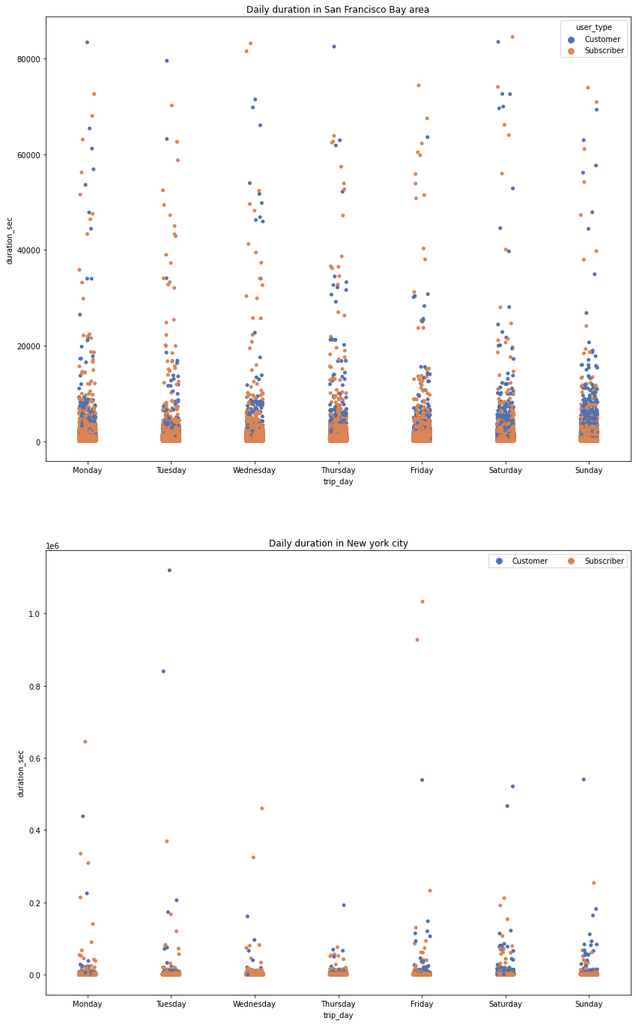

```python
# comparing user type
compare_plot('user_type')
```

> More subscribers than customers, it appears customers have the highest duration on Monday, Tuesday, and Thursday. Except for Wednesday and Friday with duration by subscribers. The user type tends to be slightly close on Saturday duration.

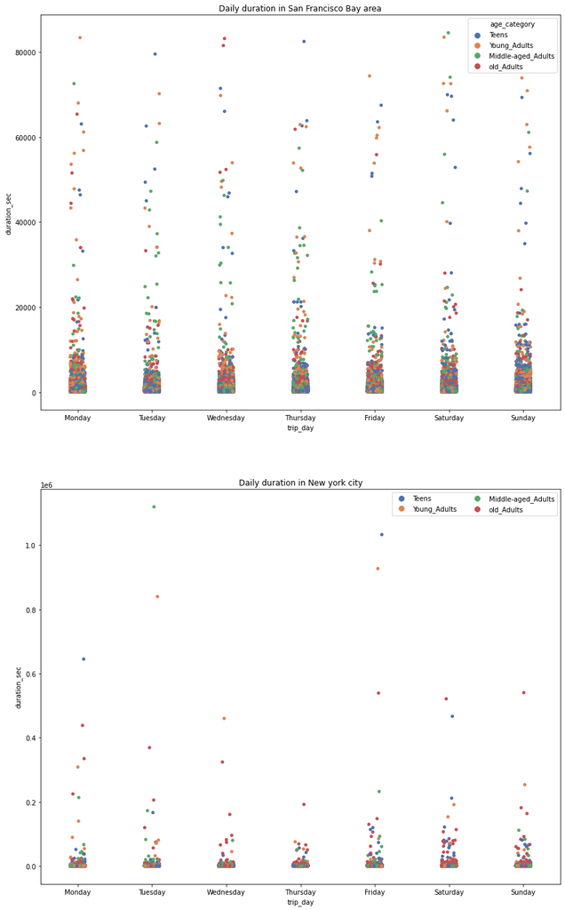

```python
# comparing city ages
compare_plot('age_category')
```

### Were there any interesting or surprising interactions between features?

> Looking at the multivariate analysis, it doesn't seem that being a subscriber member, signifies higher duration than customers. Although members are highly dense on subscribe members

## Conclusions

> The analysis of February bike rides from the San Francisco bay area and New York city was obtained for analysis. cleanup operations were required to get the dataset ready for analysis. No tidiness issues were addressed during the course of analysis, and overall insight shows no significant relationship between age and duration. All categorical variables shows no relationships rather than more participation of male subscribers on Thursdays. It was also observed there are more subscriber to customers, of which are more males than females, with teens and young adults, of age 18 - 34 taking majority of the members in both city datasets. The duration and age variable took on a large range of values, highly skewed to the right with a long tail. As result, I looked at the data using a log transform. Under the transformation, the data looked unimodal, with duration peak between 500 and 1000, and age distribution between 25 to 50 for the overall datasets.

## Limitations

> Inability to download data from given sites, to include more cities and yearly analysis.

## References

- Udacity sample projects
- Stackoverflow.com
- geeksforgeeks.org